# SubGenome Analysis

```
## [1] "This analysis is using the file ../Data/sorghum_v1_vs_maize_v1.tab"
```

# Using Sorghum as an outgroup to find syntenic regions in Maize: regenerating subgenome assignments in maize

We begin with SynMap output based on the [Schnable 2011](https://www.ncbi.nlm.nih.gov/pmc/articles/PMC3053962/) paper (see [my notes](https://www.evernote.com/shard/s303/nl/52987123/1ce74f11-98a0-4854-b363-3172e79eeae3) for details on parameter and download options).

## Preprocessing to generate a tidy dataset

We parse the SynMap output file with ks/kn values (i.e. a DAGChainer file) to a flat format using a perl script (parseKsKnFile.pl) and import the data into R. Some ks and kn values are empty, so we clean the dataset by removing all incomplete observations.

We have imported 26046 lines from the parsed SynMap file and removed 4787 incomplete rows resulting in 21259 syntenic genes.

We need to select a cutoff value for ks (synonymous mutation rate) to differentiate between the most recent alpha duplication event and the previous beta duplication. If the vertical line separates the first two peaks sufficently, it is probably a good enough value. If not, we need to pick a new cutoff value for ks.

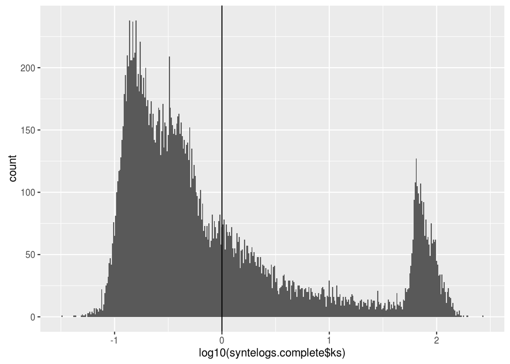

In order to separate subgenome 1 from subgenome 2, we need to find syntenic blocks of 12 or more with a median ks value below the cutoff to determine syntelogs which are related to the alpha duplication event. For each chromosome with duplicate genes, the chromosome that has the largest syntenic block is the dominant subgenome, and the lesser sized blocks on other chromosomes are the recessive subgenome.

> But how to group subgenomes over multiple chromosomes?

Table

| org_chr1 | b8082_1 | b8082_10 | b8082_2 | b8082_3 | b8082_4 | b8082_5 | b8082_6 | b8082_7 | b8082_8 | b8082_9 | total |
| --- | --- | --- | --- | --- | --- | --- | --- | --- | --- | --- | --- |
| a6807_9 | 0 | 41 | 0 | 0 | 0 | 0 | 643 | 0 | 369 | 0 | 1053 |
| a6807_8 | 153 | 171 | 0 | 207 | 0 | 0 | 15 | 0 | 0 | 0 | 546 |
| a6807_7 | 358 | 138 | 0 | 0 | 342 | 0 | 72 | 0 | 0 | 0 | 910 |
| a6807_6 | 0 | 546 | 816 | 0 | 0 | 0 | 0 | 0 | 0 | 0 | 1362 |
| a6807_5 | 0 | 19 | 157 | 12 | 300 | 0 | 0 | 0 | 0 | 0 | 488 |
| a6807_4 | 0 | 0 | 0 | 0 | 708 | 1126 | 0 | 0 | 0 | 0 | 1834 |
| a6807_3 | 0 | 0 | 0 | 1447 | 0 | 0 | 0 | 0 | 926 | 0 | 2373 |
| a6807_2 | 0 | 0 | 681 | 0 | 0 | 0 | 0 | 1226 | 0 | 0 | 1907 |
| a6807_10 | 0 | 0 | 0 | 0 | 0 | 159 | 415 | 0 | 0 | 553 | 1127 |
| a6807_1 | 1820 | 0 | 0 | 0 | 0 | 499 | 0 | 0 | 0 | 564 | 2883 |

There are 0 unaligned sorghum chromosome(s) in the above table.